# Análisis de las mejores 100 universidades del mundo

Diciembre de 2021 (actualizado el 15-12-2021)

## Análisis de las mejores 100 universidades del mundo

- Objetivo del trabajo: Visualizar los datos provinientes de tres ránkings diferentes para ver cuáles han sido las mejores universidades del mundo durante el período 2012-2015.

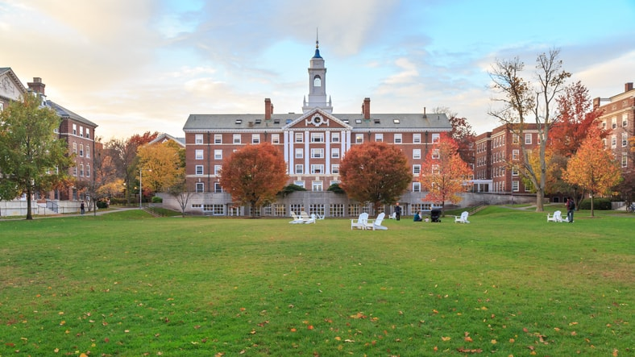

## Datos

## ¿Qué ránkings vamos a analizar?

- Vamos a intentar mostrar todos los datos de la manera más visual posible, a través de gráficos y tablas.
- Nuestros ránkings de referencia serán:
  - [Center for World University Rankings](https://cwur.org/), que desde su fundación en *2012* recopila los datos de las mejores universidades desde **Arabia Saudita**. Es en el que más nos vamos a centrar debido a la calidad de sus datos.
  - [Times Higher Education World University Ranking](https://www.timeshighereducation.com/content/world-university-rankings), fundado en **Reino Unido** en *2010*, es una de las clasificaciones más influyentes del momento, aunque algo criticado por su especial fijación en las universidades inglesas.
  - [Academic Ranking of World Universities](http://www.shanghairanking.com/), más conocido como el tan influyente **Shangai Ranking**, que comenzó a publicar sus listados en *2003*.

## Preguntas de investigación

## CENTER FOR WORLD UNIVERSITY RANKINGS

- Para empezar, hemos querido saber **qué país tiene más instituciones en el ránking** para cada año por separado. Lo hemos analizado teniendo en cuenta tanto el top 50 como el top 100.
- Aquí vemos un ejemplo de una de las tablas, en este caso en referencia al año 2012 y teniendo en cuenta el top 100.

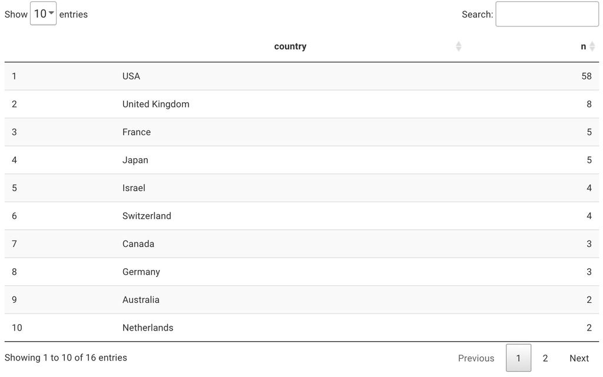

## EE.UU como claro ganador

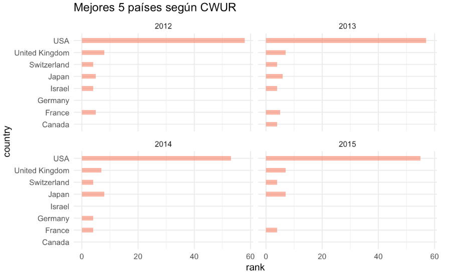

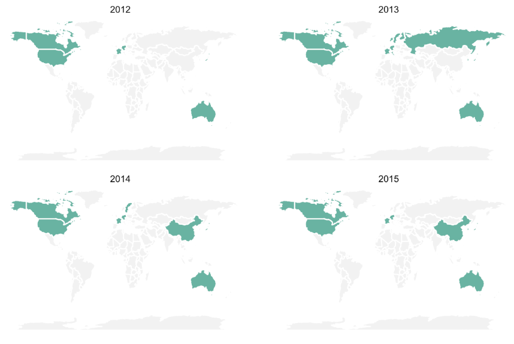

## Comparación con otro ránking

- Podemos ver la **diferencia de países** comparando los datos de *CWUR* con los de *Times*, y este es el resultado
- **CENTER FOR WORLD UNIVERSITY RANKINGS**:

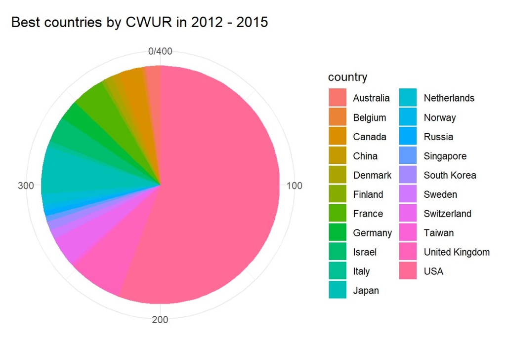

- **TIMES HIGHER EDUCATION WORLD UNIVERSITY RANKING**:

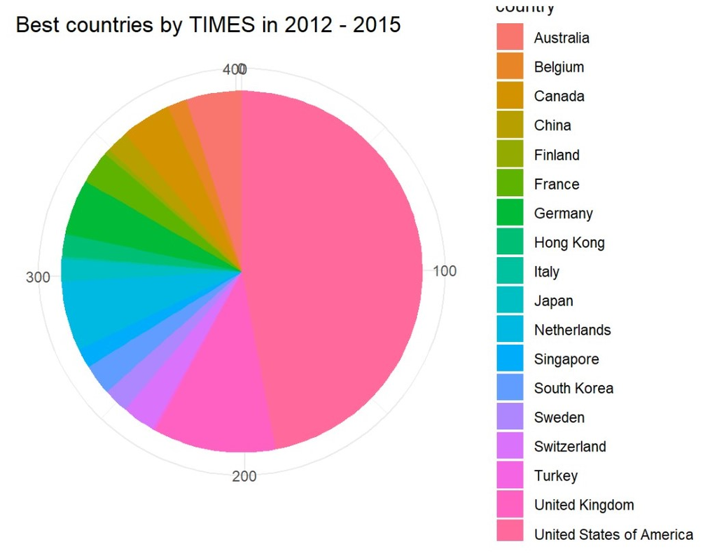

## Mejores universidades

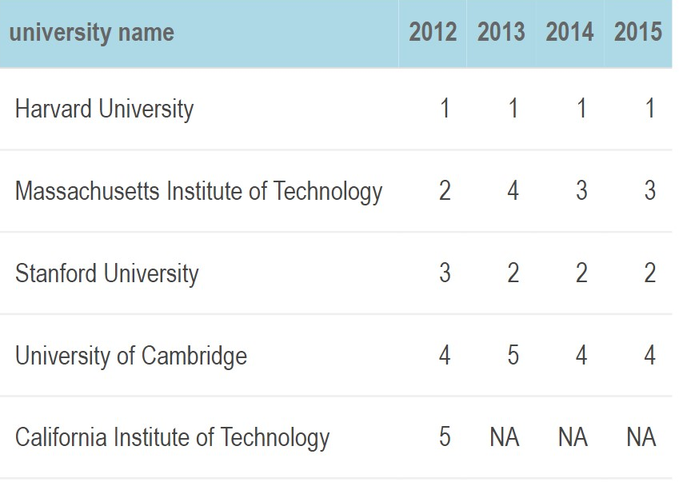

## Massachusetts Institute of Technology

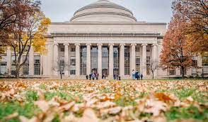

## Universidad de Stanford

[figure not shown]

## Relación entre el ránking y otras variables

- Estas unis son las mejores pero, *¿se ve eso **reflejado** en otras variables?*
- SÍ! En uno de los gráficos incluidos para cada año, vemos cómo el posicionamiento respecto a las **patentes**, **empleabilidad** de alumnos o el número de **citas** tiene que ver con el posicionamiento en el ránking global.

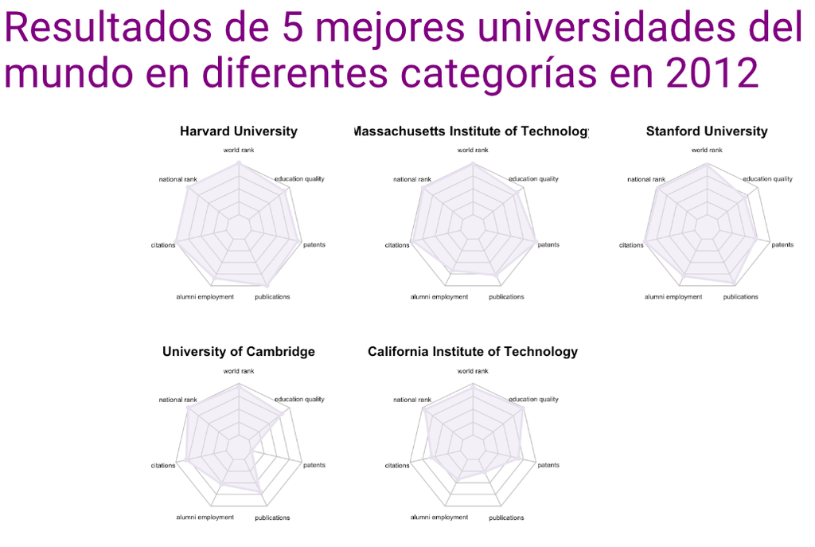

- Además, centrandonos en la **calidad de la educación** y **posterior empleabilidad**, observamos como las universidades se clasifican mejor en calidad de la eduación que en empleabilidad.

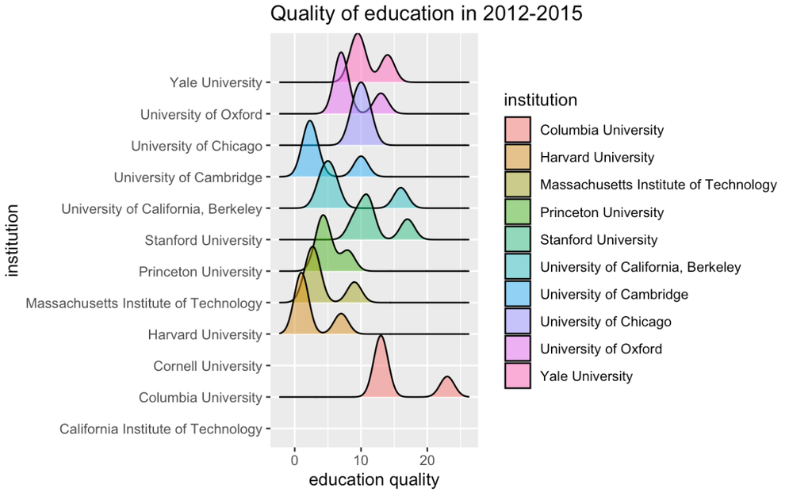

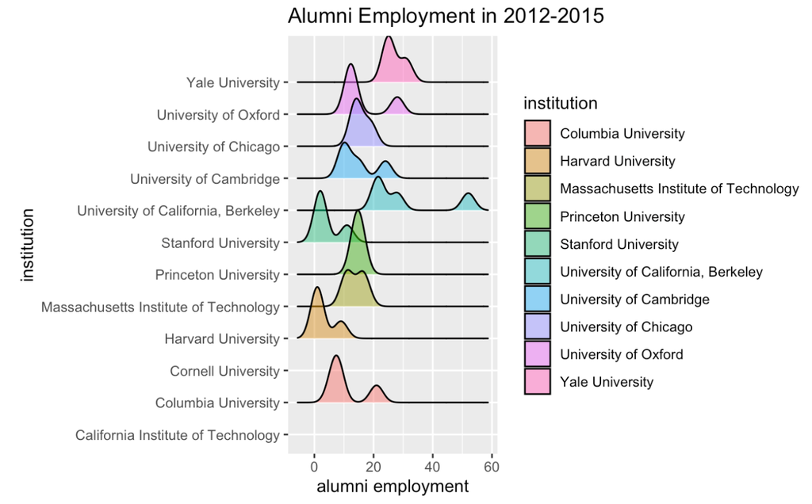

## TIMES HIGHER EDUCATION WORLD UNIVERSITY RANKING

- Nos centramos ahora en otro dataset y vamos a hacernos diferentes preguntas.
- Primero, *¿cuáles han sido las **cinco mejores universidades según Times**?*

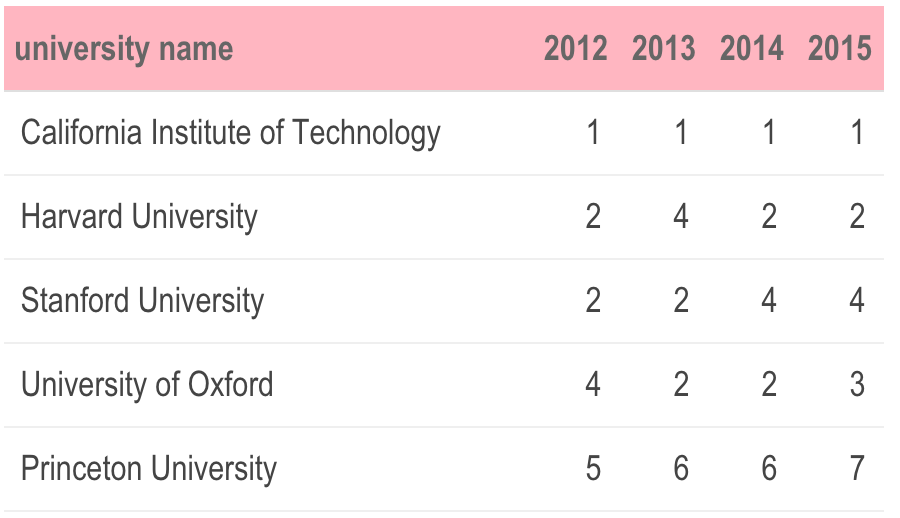

*¿Cuál es el **número de estudiantes matriculados** en las 20 mejores universidades a lo largo del tiempo?* En realidad es un gráfico dinámico, pero aquí mostramos los datos para 2014.

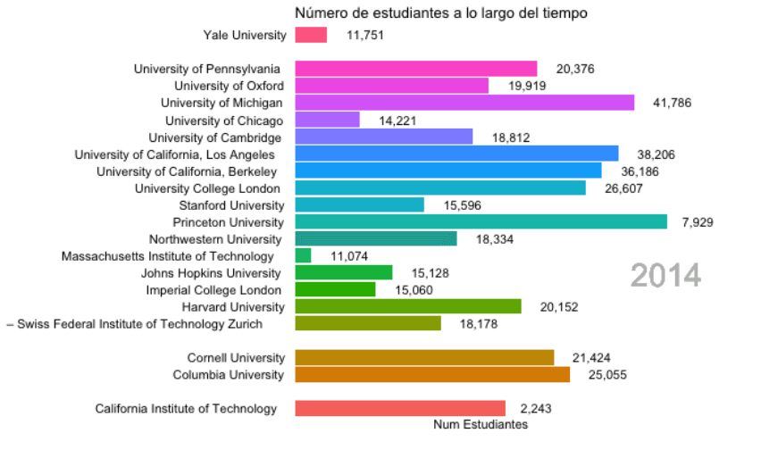

La relación entre las **mejores universidades** y el **porcentaje** de **estudiantes extranjeros**:

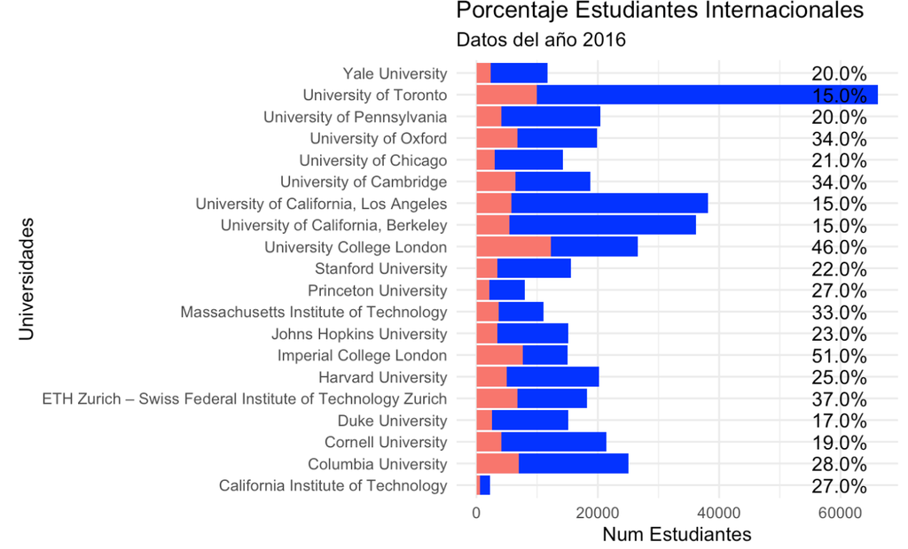

## ACADEMIC RANKING OF WORKD UNIVERSITIES

*¿Cuáles han sido las **cinco mejores universidades** según el ránking de Shanghai?*

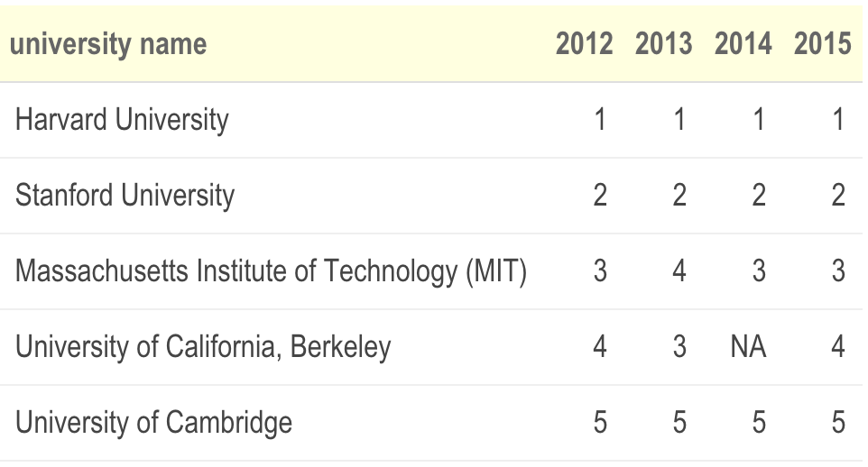

## Alumni y Profesores ganadores de premios Nobel y medallas Fields

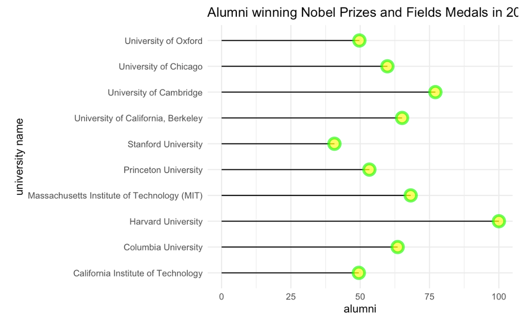

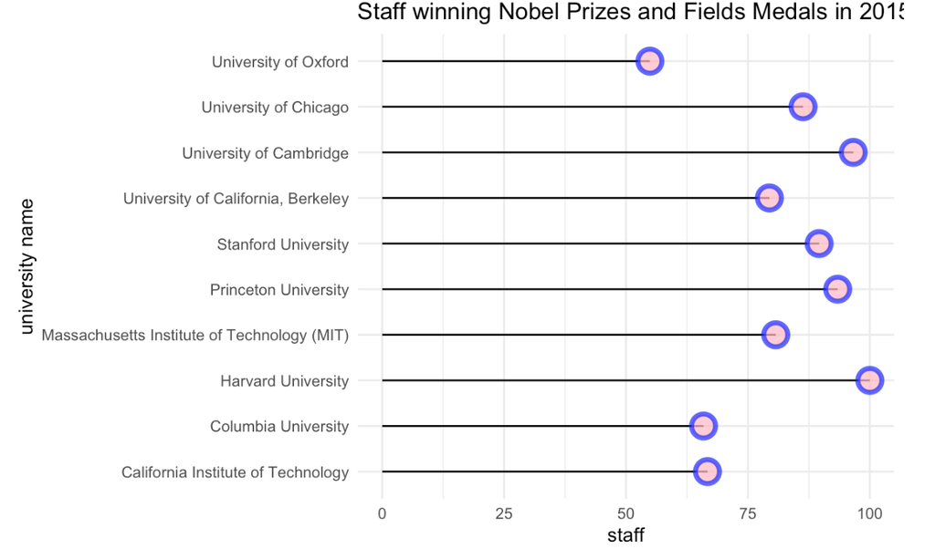

## Conclusiones

- Hemos analizado los datos mediante gráficos y tablas y hemos visto como cada ránking ofrece **información diversa**.
- **EEUU** es el país con las **mejores universidades** en todo el mundo.
- Un buen posicionamiento en el ránking mundial tiene relación con una elevada posición respecto a otras variables (*citas, publicaciones, empleabilidad…*)
- Las mejores universidades suelen **mantener su estatus** y hay escasos cambios significativos en el ránking.
- Observamos diferentes clasificaciones dependiendo de la institución que elabora el ránking.

## Bibliografía

Nos hemos basado en diferentes fuentes y trabajos ya existentes, como:

- World University Rankings Advanced Analysis
- Análisis sobre la Covid-19
- Página web de Kaggle
- Galería de gráficos de ggplot
- La página web del curso
- What impact does university reputation have on students?
- Univesidades líderes en el mundo. El posicionamiento de España. 2020
- Y. Bano, S. Vasantha. Influence Of University Reputation On Employability. 2019